# Malathion - FST estimates

Luciano V Cosme

2023-12-18

# Analysis code

## Libraries

```r
library(StAMPP)
library(ggplot2)
library(tidyverse)
library(colorout)
library(here)
library(reshape2)
library(dplyr)
library(tidyr)
library(dartR)
library(Cairo)
library(data.table)
library(scales)
```

We can use different data sets to run our fst estimates.

Clean env and memory

```r
# Remove all objects from the environment
rm(list = ls())

# Run the garbage collector to free up memory
gc()
```

```
##           used  (Mb) gc trigger  (Mb) limit (Mb) max used  (Mb)
## Ncells 5776000 308.5    9400914 502.1         NA  7427223 396.7
## Vcells 9511108  72.6   14786712 112.9      32768 12088629  92.3
```

## 1. Estimate pairwise FST for all populations

We can convert to raw format

```bash
plink \
--keep-allele-order \
--bfile output/quality_control/file10 \
--recodeA \
--out output/fst/file1 \
--silent;
grep 'samples\|variants\|remaining' output/fst/file1.log
```

```
## 10157 variants loaded from .bim file.
## 10157 variants and 89 people pass filters and QC.
```

Look at https://rdrr.io/cran/StAMPP/man/stamppFst.html for details of Fst estimations

```r
pop_pairwise <-
  read.PLINK(
    here(
      "output", "fst", "file1.raw"
    ),
    quiet = FALSE,
    chunkSize = 1000,
    parallel = require("parallel"),
    n.cores = 4
  )

summary(pop_pairwise)
```

Now lets convert the genlight object to Stampp format, and estimate pairwise Fst values

The command below would also work, but you can simplify it and put only the numbers: pop_pairwise2 <- stamppFst(pop_pairwise, nboots=10, percent=95 + nclusters=8)

This chunk will take a couple minutes to run.

```r
# Convert
pop_pairwise2 <- stamppConvert(pop_pairwise, type="genlight")

# I am runing with 10 bootstraps, using 95% percentile to calculate confidence intervals, and 8 threads
pop_pairwise2 <- stamppFst(pop_pairwise2, 10, 95, 8)
```

Save it, so we do not have to run it again

```r
saveRDS(
  pop_pairwise2, here(
    "output", "fst", "pop_pairwise2.rds"
  )
)
```

To load it

```r
pop_pairwise2 <- readRDS(
  here(
    "output", "fst", "pop_pairwise2.rds"
  )
)
```

Now lets look at the object

```r
summary(pop_pairwise2)
```

```
##            Length Class      Mode
## Fsts       25     -none-     numeric
## Pvalues    25     -none-     numeric
## Bootstraps 16     data.frame list
```

If you want you can save the fst values as csv.

```r
# Convert to data frame
pop_pairwise2_df <- data.frame(pop_pairwise2$Fsts)

# Save it
write.csv(pop_pairwise2_df, file = here("output", "fst", "pop_pairwise2_df.csv"))
```

Check the Fst values

```r
pop_pairwise2_df
```

```
##                         Background_Female_Dead Background_Female_Alive
## Background_Female_Dead                      NA                      NA
## Background_Female_Alive           -0.006173003                      NA
## Background_Male_Dead               0.002243873            -0.010023192
## Selection_Female_Alive             0.009551997             0.006750734
## Selection_Male_Alive               0.007053467             0.002136812
##                         Background_Male_Dead Selection_Female_Alive
## Background_Female_Dead                    NA                     NA
## Background_Female_Alive                   NA                     NA
## Background_Male_Dead                      NA                     NA
## Selection_Female_Alive          0.0015964819                     NA
## Selection_Male_Alive           -0.0006100427           -0.002698563
##                         Selection_Male_Alive
## Background_Female_Dead                    NA
## Background_Female_Alive                   NA
## Background_Male_Dead                      NA
## Selection_Female_Alive                    NA
## Selection_Male_Alive                      NA
```

We can subset the object

```r
# Convert the Fsts component to a data frame
fst_df <- as.data.frame(pop_pairwise2$Fsts)

# Convert the Pvalues component to a data frame
pvalues_df <- as.data.frame(pop_pairwise2$Pvalues)

# For Bootstraps, since it's already a data frame-like structure, it can be converted directly
bootstraps_df <- as.data.frame(pop_pairwise2$Bootstraps)
```

Update names

```r
# Original long names
long_names <- c("Background_Female_Dead", "Background_Male_Dead", "Selection_Female_Alive", "Selection_Male_Alive", "Background_Female_Alive")

# Create a mapping of long names to short names
name_mapping <- setNames(c("B_F_D", "B_M_D", "S_F_A", "S_M_A", "B_F_A"), long_names)

# Assuming 'fst_df' is your data frame containing Fst values
# Replace row names
rownames(fst_df) <- name_mapping[rownames(fst_df)]

# Replace column names
colnames(fst_df) <- name_mapping[colnames(fst_df)]

# Now 'fst_df' has the shorter names for plotting
print(fst_df)
```

```
##              B_F_D        B_F_A         B_M_D        S_F_A S_M_A
## B_F_D           NA           NA            NA           NA    NA
## B_F_A -0.006173003           NA            NA           NA    NA
## B_M_D  0.002243873 -0.010023192            NA           NA    NA
## S_F_A  0.009551997  0.006750734  0.0015964819           NA    NA
## S_M_A  0.007053467  0.002136812 -0.0006100427 -0.002698563    NA
```

We will convert the data into a matrix.

```r
# Create matrix
aa <- as.matrix(fst_df)
aa[upper.tri(aa)] <- t(aa)[upper.tri(t(aa))]
head(aa)
```

```
##              B_F_D        B_F_A         B_M_D        S_F_A         S_M_A
## B_F_D           NA -0.006173003  0.0022438732  0.009551997  0.0070534665
## B_F_A -0.006173003           NA -0.0100231923  0.006750734  0.0021368116
## B_M_D  0.002243873 -0.010023192            NA  0.001596482 -0.0006100427
## S_F_A  0.009551997  0.006750734  0.0015964819           NA -0.0026985625
## S_M_A  0.007053467  0.002136812 -0.0006100427 -0.002698563            NA
```

Lets check if the matrix is symmetric.

```r
isSymmetric(aa)
```

```
## [1] TRUE
```

We will also add NA on the upper left side of the matrix.

```r
aa[lower.tri(aa)] <- NA
```

Now we have to convert the matrix to a data frame to plot it with ggplot.

```r
pairfst.long <- reshape2::melt(aa)
summary(pairfst.long)
```

```
##     Var1      Var2       value
##  B_F_D:5   B_F_D:5   Min.   :-0.010023
##  B_F_A:5   B_F_A:5   1st Qu.:-0.002176
##  B_M_D:5   B_M_D:5   Median : 0.001867
##  S_F_A:5   S_F_A:5   Mean   : 0.000983
##  S_M_A:5   S_M_A:5   3rd Qu.: 0.005624
##                      Max.   : 0.009552
##                      NA's   :15
```

Now lets plot the data with ggplot. You can click in the little square on the top left of the plot to open it on a new window. It will have the right proportions.

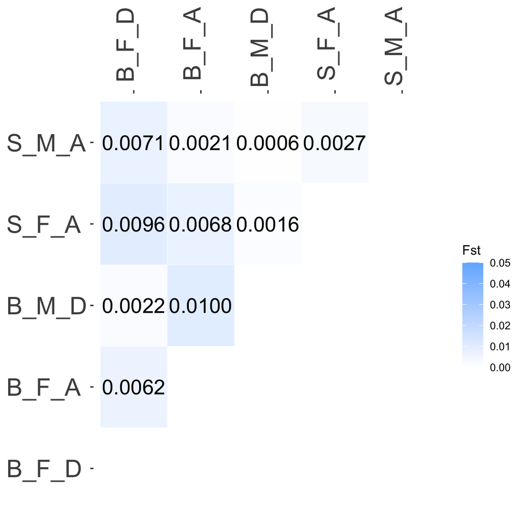

```r
# Apply abs() to the 'value' column to get the absolute values
pairfst.long$value <- abs(pairfst.long$value)

pairfst.f <- ggplot(pairfst.long, aes(Var1, Var2)) +
  geom_tile(aes(fill = value), colour = "white") +
  scale_fill_gradient(
    low = "white",
    high = "#71b6ff",
    name = "Fst",
    na.value = "white",
    limits = c(0, 0.05)
  ) +
  scale_x_discrete(position = "top") +
  theme_bw() +
  geom_text(aes(label = ifelse(
    is.na(value), "", formatC(value, digits = 4, format = "f")
  )), size = 6) +
  theme(
    axis.text.x = element_text(angle = 90, hjust = 1, size = 20),
    axis.title = element_blank(),
    panel.grid.major = element_blank(),
    panel.grid.minor = element_blank(),
    panel.border = element_blank(),
    panel.background = element_blank(),
    axis.text.y = element_text(hjust = 0, size = 20)
  )
pairfst.f
```

```r
output_path <- here("output", "fst", "figures", "pairwise_estimates.pdf")
ggsave(output_path, pairfst.f, height = 6, width = 6, dpi = 300)
```

## 2. Sliding windows Fst estimates between the populations

Clean env and memory

```r
# Remove all objects from the environment
rm(list = ls())

# Run the garbage collector to free up memory
gc()
```

```
##           used  (Mb) gc trigger  (Mb) limit (Mb) max used  (Mb)
## Ncells 5938097 317.2    9400914 502.1         NA  9112564 486.7
## Vcells 9836829  75.1   17824054 136.0      32768 14786689 112.9
```

First we need to create a vcf with Plink. We can use the original file since we will compare all populations.

Convert to vcf

```bash
plink2 \
--keep-allele-order \
--bfile output/quality_control/file10 \
--recode vcf-4.2 id-delim="." \
--out output/fst/malathion \
--silent;
grep 'samples\|variants\|remaining' output/fst/malathion.log
```

```
## 89 samples (46 females, 43 males; 89 founders) loaded from
## 10157 variants loaded from output/quality_control/file10.bim.
```

We can use bfctools to check the sample names

```bash
bcftools query -l output/fst/malathion.vcf
```

```
## Background_Female_Dead.49
## Background_Female_Dead.50
## Background_Female_Dead.51
## Background_Female_Dead.52
## Background_Female_Dead.53
## Background_Female_Dead.54
## Background_Female_Dead.55
## Background_Female_Dead.56
## Background_Female_Dead.57
## Background_Female_Dead.58
## Background_Female_Alive.60
## Background_Male_Dead.61
## Background_Male_Dead.62
## Background_Male_Dead.63
## Background_Male_Dead.64
## Background_Male_Dead.65
## Background_Male_Dead.66
## Background_Male_Dead.67
## Background_Male_Dead.68
## Background_Male_Dead.69
## Background_Male_Dead.70
## Background_Female_Alive.71
## Background_Female_Alive.72
## Background_Female_Dead.73
## Background_Female_Dead.74
## Background_Female_Dead.75
## Background_Female_Dead.76
## Background_Female_Dead.77
## Background_Female_Dead.78
## Background_Female_Dead.80
## Background_Female_Dead.81
## Background_Female_Dead.82
## Background_Female_Alive.83
## Background_Male_Dead.85
## Background_Male_Dead.86
## Background_Male_Dead.87
## Background_Male_Dead.88
## Background_Male_Dead.89
## Background_Male_Dead.90
## Background_Male_Dead.91
```

[output cut: 34 more lines]

```
## Selection_Female_Alive.33
## Selection_Female_Alive.34
## Selection_Female_Alive.35
## Selection_Female_Alive.36
## Selection_Male_Alive.37
## Selection_Male_Alive.38
## Selection_Male_Alive.39
## Selection_Male_Alive.40
## Selection_Male_Alive.42
## Selection_Male_Alive.43
## Selection_Male_Alive.44
## Selection_Male_Alive.45
## Selection_Male_Alive.46
## Selection_Male_Alive.47
## Selection_Male_Alive.48
```

Now we create a list of mosquitoes for each population

```bash
# Define the VCF file path
VCF_FILE="output/fst/malathion.vcf"

# Extract the list of individuals
INDIVIDUALS=$(bcftools query -l $VCF_FILE)

# Filter and create files for each population
echo "$INDIVIDUALS" | grep 'Selection_Male_Alive' > output/fst/sma.txt
echo "$INDIVIDUALS" | grep 'Selection_Female_Alive' > output/fst/sfa.txt
echo "$INDIVIDUALS" | grep 'Background_Male_Dead' > output/fst/bmd.txt
echo "$INDIVIDUALS" | grep 'Background_Female_Dead' > output/fst/bfd.txt
echo "$INDIVIDUALS" | grep 'Background_Female_Alive' > output/fst/bfa.txt
```

Check one file to see if is correct

```bash
head output/fst/sma.txt
```

```
## Selection_Male_Alive.13
## Selection_Male_Alive.14
## Selection_Male_Alive.15
## Selection_Male_Alive.16
## Selection_Male_Alive.17
## Selection_Male_Alive.18
## Selection_Male_Alive.19
## Selection_Male_Alive.20
## Selection_Male_Alive.21
## Selection_Male_Alive.22
```

Now we can estimate Fst between the populations using vcftools. We can use overlapping windows for finer resolution

Male (S) vs males (B)

```bash
# Since we are using the SNP chip data, we can use a window of 1Mb and 100kb steps
vcftools --vcf output/fst/malathion.vcf \
         --weir-fst-pop output/fst/sma.txt \
         --weir-fst-pop output/fst/bmd.txt \
         --fst-window-size 1000000 \
         --fst-window-step 100000 \
         --out output/fst/maleS_maleB
```

```
##
## VCFtools - 0.1.16
## (C) Adam Auton and Anthony Marcketta 2009
##
## Parameters as interpreted:
##  --vcf output/fst/malathion.vcf
##  --fst-window-size 1000000
##  --fst-window-step 100000
##  --weir-fst-pop output/fst/sma.txt
##  --weir-fst-pop output/fst/bmd.txt
##  --keep output/fst/sma.txt
##  --keep output/fst/bmd.txt
##  --out output/fst/maleS_maleB
##
## Warning: Expected at least 2 parts in INFO entry: ID=PR,Number=0,Type=Flag,Description="Provisional reference allele, may not be based on real reference genome">
## Keeping individuals in 'keep' list
## After filtering, kept 43 out of 89 Individuals
## Outputting Windowed Weir and Cockerham Fst estimates.
## Weir and Cockerham mean Fst estimate: -0.00079586
## Weir and Cockerham weighted Fst estimate: -0.00061004
## After filtering, kept 10157 out of a possible 10157 Sites
## Run Time = 1.00 seconds
```

Check the result

```bash
head output/fst/maleS_maleB.windowed.weir.fst
```

```
## CHROM    BIN_START   BIN_END N_VARIANTS  WEIGHTED_FST    MEAN_FST
## 1    1   1000000 10  0.00323287  0.00403334
## 1    100001  1100000 10  2.89113e-05 -0.000160356
## 1    200001  1200000 7   -0.0118486  -0.0136636
## 1    300001  1300000 7   -0.0118486  -0.0136636
## 1    400001  1400000 8   -0.0123562  -0.0139112
## 1    500001  1500000 6   -0.0150727  -0.0158493
## 1    600001  1600000 6   -0.0150727  -0.0158493
## 1    700001  1700000 5   -0.0210295  -0.0207902
## 1    800001  1800000 4   -0.0194846  -0.0195385
```

Female (S) vs females (B)

```bash
# Since we are using the SNP chip data, we can use a window of 1Mb and 100kb steps
vcftools --vcf output/fst/malathion.vcf \
         --weir-fst-pop output/fst/sfa.txt \
         --weir-fst-pop output/fst/bfd.txt \
         --fst-window-size 1000000 \
         --fst-window-step 100000 \
         --out output/fst/femaleS_femaleB
```

```
##
## VCFtools - 0.1.16
## (C) Adam Auton and Anthony Marcketta 2009
##
## Parameters as interpreted:
##  --vcf output/fst/malathion.vcf
##  --fst-window-size 1000000
##  --fst-window-step 100000
##  --weir-fst-pop output/fst/sfa.txt
##  --weir-fst-pop output/fst/bfd.txt
##  --keep output/fst/sfa.txt
##  --keep output/fst/bfd.txt
##  --out output/fst/femaleS_femaleB
##
## Warning: Expected at least 2 parts in INFO entry: ID=PR,Number=0,Type=Flag,Description="Provisional reference allele, may not be based on real reference genome">
## Keeping individuals in 'keep' list
## After filtering, kept 41 out of 89 Individuals
## Outputting Windowed Weir and Cockerham Fst estimates.
## Weir and Cockerham mean Fst estimate: 0.0068314
## Weir and Cockerham weighted Fst estimate: 0.009552
## After filtering, kept 10157 out of a possible 10157 Sites
## Run Time = 1.00 seconds
```

Selection Male vs Female

```bash
# Since we are using the SNP chip data, we can use a window of 1Mb and 100kb steps
vcftools --vcf output/fst/malathion.vcf \
         --weir-fst-pop output/fst/sma.txt \
         --weir-fst-pop output/fst/sfa.txt \
         --fst-window-size 1000000 \
         --fst-window-step 100000 \
         --out output/fst/maleS_femaleS
```

```
##
## VCFtools - 0.1.16
## (C) Adam Auton and Anthony Marcketta 2009
##
## Parameters as interpreted:
##  --vcf output/fst/malathion.vcf
##  --fst-window-size 1000000
##  --fst-window-step 100000
##  --weir-fst-pop output/fst/sma.txt
##  --weir-fst-pop output/fst/sfa.txt
##  --keep output/fst/sma.txt
##  --keep output/fst/sfa.txt
##  --out output/fst/maleS_femaleS
##
## Warning: Expected at least 2 parts in INFO entry: ID=PR,Number=0,Type=Flag,Description="Provisional reference allele, may not be based on real reference genome">
## Keeping individuals in 'keep' list
## After filtering, kept 45 out of 89 Individuals
## Outputting Windowed Weir and Cockerham Fst estimates.
## Weir and Cockerham mean Fst estimate: -0.0028178
## Weir and Cockerham weighted Fst estimate: -0.0026986
## After filtering, kept 10157 out of a possible 10157 Sites
## Run Time = 0.00 seconds
```

Background Male vs Female

```bash
# Since we are using the SNP chip data, we can use a window of 1Mb and 100kb steps
vcftools --vcf output/fst/malathion.vcf \
         --weir-fst-pop output/fst/bmd.txt \
         --weir-fst-pop output/fst/bfd.txt \
         --fst-window-size 1000000 \
         --fst-window-step 100000 \
         --out output/fst/maleB_femaleB
```

```
##
## VCFtools - 0.1.16
## (C) Adam Auton and Anthony Marcketta 2009
##
## Parameters as interpreted:
##  --vcf output/fst/malathion.vcf
##  --fst-window-size 1000000
##  --fst-window-step 100000
##  --weir-fst-pop output/fst/bmd.txt
##  --weir-fst-pop output/fst/bfd.txt
##  --keep output/fst/bmd.txt
##  --keep output/fst/bfd.txt
##  --out output/fst/maleB_femaleB
##
## Warning: Expected at least 2 parts in INFO entry: ID=PR,Number=0,Type=Flag,Description="Provisional reference allele, may not be based on real reference genome">
## Keeping individuals in 'keep' list
## After filtering, kept 39 out of 89 Individuals
## Outputting Windowed Weir and Cockerham Fst estimates.
## Weir and Cockerham mean Fst estimate: 0.00085713
## Weir and Cockerham weighted Fst estimate: 0.0022439
## After filtering, kept 10157 out of a possible 10157 Sites
## Run Time = 0.00 seconds
```

Background dead (S) vs background alive (B)

```bash
# Since we are using the SNP chip data, we can use a window of 1Mb and 100kb steps
vcftools --vcf output/fst/malathion.vcf \
         --weir-fst-pop output/fst/bfd.txt \
         --weir-fst-pop output/fst/bfa.txt \
         --fst-window-size 1000000 \
         --fst-window-step 100000 \
         --out output/fst/backgroundD_backgroundA
```

```
##
## VCFtools - 0.1.16
## (C) Adam Auton and Anthony Marcketta 2009
##
## Parameters as interpreted:
##  --vcf output/fst/malathion.vcf
##  --fst-window-size 1000000
##  --fst-window-step 100000
##  --weir-fst-pop output/fst/bfd.txt
##  --weir-fst-pop output/fst/bfa.txt
##  --keep output/fst/bfd.txt
##  --keep output/fst/bfa.txt
##  --out output/fst/backgroundD_backgroundA
##
## Warning: Expected at least 2 parts in INFO entry: ID=PR,Number=0,Type=Flag,Description="Provisional reference allele, may not be based on real reference genome">
## Keeping individuals in 'keep' list
## After filtering, kept 24 out of 89 Individuals
## Outputting Windowed Weir and Cockerham Fst estimates.
## Weir and Cockerham mean Fst estimate: -0.010155
## Weir and Cockerham weighted Fst estimate: -0.006173
## After filtering, kept 10157 out of a possible 10157 Sites
## Run Time = 1.00 seconds
```

Check the result

```bash
head output/fst/backgroundD_backgroundA.windowed.weir.fst
```

```
## CHROM    BIN_START   BIN_END N_VARIANTS  WEIGHTED_FST    MEAN_FST
## 1    1   1000000 10  -0.0405527  -0.0405144
## 1    100001  1100000 9   -0.0398035  -0.0397118
## 1    200001  1200000 6   -0.0168531  -0.0179919
## 1    300001  1300000 6   -0.0168531  -0.0179919
## 1    400001  1400000 7   -0.024364   -0.0238585
## 1    500001  1500000 5   -0.02074    -0.0200327
## 1    600001  1600000 5   -0.02074    -0.0200327
## 1    700001  1700000 4   -0.0312001  -0.0293702
## 1    800001  1800000 3   -0.0318582  -0.0293904
```

Background alive (S) vs selection alive (B)

```bash
# Since we are using the SNP chip data, we can use a window of 1Mb and 100kb steps
vcftools --vcf output/fst/malathion.vcf \
         --weir-fst-pop output/fst/bfa.txt \
         --weir-fst-pop output/fst/sfa.txt \
         --fst-window-size 1000000 \
         --fst-window-step 100000 \
         --out output/fst/backgroundA_selectionA
```

```
##
## VCFtools - 0.1.16
## (C) Adam Auton and Anthony Marcketta 2009
##
## Parameters as interpreted:
##  --vcf output/fst/malathion.vcf
##  --fst-window-size 1000000
##  --fst-window-step 100000
##  --weir-fst-pop output/fst/bfa.txt
##  --weir-fst-pop output/fst/sfa.txt
##  --keep output/fst/bfa.txt
##  --keep output/fst/sfa.txt
##  --out output/fst/backgroundA_selectionA
##
## Warning: Expected at least 2 parts in INFO entry: ID=PR,Number=0,Type=Flag,Description="Provisional reference allele, may not be based on real reference genome">
## Keeping individuals in 'keep' list
## After filtering, kept 27 out of 89 Individuals
## Outputting Windowed Weir and Cockerham Fst estimates.
## Weir and Cockerham mean Fst estimate: 0.0022082
## Weir and Cockerham weighted Fst estimate: 0.0067507
## After filtering, kept 10157 out of a possible 10157 Sites
## Run Time = 0.00 seconds
```

Now we can import the results into R Male (S) vs males (B)

```r
# Define the file path using here
file_path <- here("output", "fst", "maleS_maleB.windowed.weir.fst")

# Import the file using read_delim
maleS_maleB <- read_delim(file_path,
                       delim = "\t",    # Specify the tab delimiter
                       col_names = TRUE,
                      show_col_types = FALSE) # Indicates that the first row contains column names

# View the first few rows of the data
head(maleS_maleB)
```

```
## # A tibble: 6 × 6
##   CHROM BIN_START BIN_END N_VARIANTS WEIGHTED_FST  MEAN_FST
##   <dbl>     <dbl>   <dbl>      <dbl>        <dbl>     <dbl>
## 1     1         1 1000000         10    0.00323    0.00403
## 2     1    100001 1100000         10    0.0000289 -0.000160
## 3     1    200001 1200000          7   -0.0118    -0.0137
## 4     1    300001 1300000          7   -0.0118    -0.0137
## 5     1    400001 1400000          8   -0.0124    -0.0139
## 6     1    500001 1500000          6   -0.0151    -0.0158
```

Female (S) vs females (B)

```r
# Define the file path using here
file_path <- here("output", "fst", "femaleS_femaleB.windowed.weir.fst")

# Import the file using read_delim
femaleS_femaleB <- read_delim(file_path,
                       delim = "\t",    # Specify the tab delimiter
                       col_names = TRUE,
                      show_col_types = FALSE) # Indicates that the first row contains column names

# View the first few rows of the data
head(femaleS_femaleB)
```

```
## # A tibble: 6 × 6
##   CHROM BIN_START BIN_END N_VARIANTS WEIGHTED_FST MEAN_FST
##   <dbl>     <dbl>   <dbl>      <dbl>        <dbl>    <dbl>
## 1     1         1 1000000         10       0.0399   0.0330
## 2     1    100001 1100000         10       0.0206   0.0197
## 3     1    200001 1200000          7       0.0256   0.0232
## 4     1    300001 1300000          7       0.0256   0.0232
## 5     1    400001 1400000          8       0.0180   0.0175
## 6     1    500001 1500000          6      -0.0231  -0.0141
```

Selection Male vs Female

```r
# Define the file path using here
file_path <- here("output", "fst", "maleS_femaleS.windowed.weir.fst")

# Import the file using read_delim
maleS_femaleS <- read_delim(file_path,
                       delim = "\t",    # Specify the tab delimiter
                       col_names = TRUE,
                      show_col_types = FALSE) # Indicates that the first row contains column names

# View the first few rows of the data
head(maleS_femaleS)
```

```
## # A tibble: 6 × 6
##   CHROM BIN_START BIN_END N_VARIANTS WEIGHTED_FST MEAN_FST
##   <dbl>     <dbl>   <dbl>      <dbl>        <dbl>    <dbl>
## 1     1         1 1000000         10       0.0384   0.0309
## 2     1    100001 1100000         10       0.0288   0.0192
## 3     1    200001 1200000          7       0.0254   0.0196
## 4     1    300001 1300000          7       0.0254   0.0196
## 5     1    400001 1400000          8       0.0360   0.0292
## 6     1    500001 1500000          6       0.0254   0.0181
```

Background Male vs Female

```r
# Define the file path using here
file_path <- here("output", "fst", "maleB_femaleB.windowed.weir.fst")

# Import the file using read_delim
maleB_femaleB <- read_delim(file_path,
                       delim = "\t",    # Specify the tab delimiter
                       col_names = TRUE,
                      show_col_types = FALSE) # Indicates that the first row contains column names

# View the first few rows of the data
head(maleB_femaleB)
```

```
## # A tibble: 6 × 6
##   CHROM BIN_START BIN_END N_VARIANTS WEIGHTED_FST MEAN_FST
##   <dbl>     <dbl>   <dbl>      <dbl>        <dbl>    <dbl>
## 1     1         1 1000000         10      0.0163   0.0195
## 2     1    100001 1100000         10      0.00756  0.0135
## 3     1    200001 1200000          7      0.00655  0.00693
## 4     1    300001 1300000          7      0.00655  0.00693
## 5     1    400001 1400000          8      0.00484  0.00552
## 6     1    500001 1500000          6     -0.00706 -0.00274
```

Background female alive vs selection female alive

```r
# Define the file path using here
file_path <- here("output", "fst", "backgroundA_selectionA.windowed.weir.fst")

# Import the file using read_delim
Famele_BA_SA <- read_delim(file_path,
                       delim = "\t",    # Specify the tab delimiter
                       col_names = TRUE,
                      show_col_types = FALSE) # Indicates that the first row contains column names

# View the first few rows of the data
head(Famele_BA_SA)
```

```
## # A tibble: 6 × 6
##   CHROM BIN_START BIN_END N_VARIANTS WEIGHTED_FST MEAN_FST
##   <dbl>     <dbl>   <dbl>      <dbl>        <dbl>    <dbl>
## 1     1         1 1000000         10     -0.0244   -0.0295
## 2     1    100001 1100000         10     -0.0309   -0.0332
## 3     1    200001 1200000          7     -0.00653  -0.0115
## 4     1    300001 1300000          7     -0.00653  -0.0115
## 5     1    400001 1400000          8     -0.00962  -0.0133
## 6     1    500001 1500000          6     -0.0174   -0.0170
```

Background female dead vs background female alive

```r
# Define the file path using here
file_path <- here("output", "fst", "backgroundD_backgroundA.windowed.weir.fst")

# Import the file using read_delim
FemalesB <- read_delim(file_path,
                       delim = "\t",    # Specify the tab delimiter
                       col_names = TRUE,
                      show_col_types = FALSE) # Indicates that the first row contains column names

# View the first few rows of the data
head(FemalesB)
```

```
## # A tibble: 6 × 6
##   CHROM BIN_START BIN_END N_VARIANTS WEIGHTED_FST MEAN_FST
##   <dbl>     <dbl>   <dbl>      <dbl>        <dbl>    <dbl>
## 1     1         1 1000000         10      -0.0406  -0.0405
## 2     1    100001 1100000          9      -0.0398  -0.0397
## 3     1    200001 1200000          6      -0.0169  -0.0180
## 4     1    300001 1300000          6      -0.0169  -0.0180
## 5     1    400001 1400000          7      -0.0244  -0.0239
## 6     1    500001 1500000          5      -0.0207  -0.0200
```

Combine the data

```r
# Add a new column 'comparison' to each tibble
maleS_maleB$comparison <- "Males"
femaleS_femaleB$comparison <- "Females"
maleS_femaleS$comparison <- "SexS"
maleB_femaleB$comparison <- "SexB"
FemalesB$comparison <- "FemalesB"
Famele_BA_SA$comparison <- "FemalesSBA"

# Combine the tibbles using rbind
combined_data <- rbind(maleS_maleB, femaleS_femaleB, maleS_femaleS, maleB_femaleB, FemalesB, Famele_BA_SA)

# View the first few rows of the combined data
head(combined_data)
```

```
## # A tibble: 6 × 7
##   CHROM BIN_START BIN_END N_VARIANTS WEIGHTED_FST  MEAN_FST comparison
##   <dbl>     <dbl>   <dbl>      <dbl>        <dbl>     <dbl> <chr>
## 1     1         1 1000000         10    0.00323    0.00403  Males
## 2     1    100001 1100000         10    0.0000289 -0.000160 Males
## 3     1    200001 1200000          7   -0.0118    -0.0137   Males
## 4     1    300001 1300000          7   -0.0118    -0.0137   Males
## 5     1    400001 1400000          8   -0.0124    -0.0139   Males
## 6     1    500001 1500000          6   -0.0151    -0.0158   Males
```

```r
unique(combined_data$comparison)
```

```
## [1] "Males"      "Females"    "SexS"       "SexB"       "FemalesB"
## [6] "FemalesSBA"
```

Now we plot

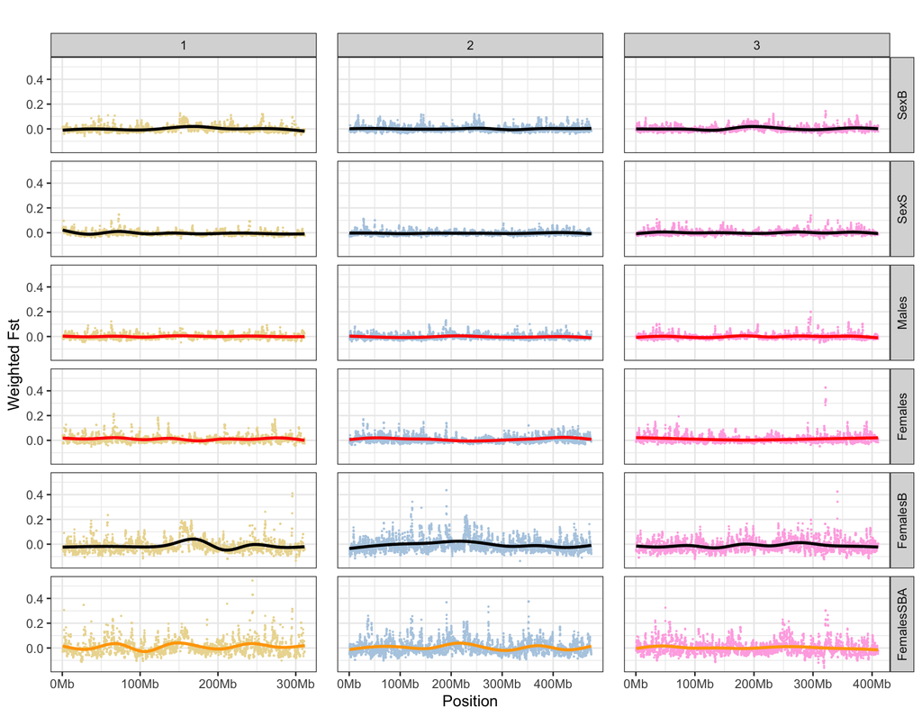

```r
# Calculate the middle position
combined_data$mid_pos <- with(combined_data, (BIN_START + BIN_END) / 2)

# Reorder the levels of the comparison factor
combined_data$comparison <- fct_relevel(combined_data$comparison, "SexB", "SexS", "Males", "Females", "FemalesB", "FemalesSBA")

# Define a set of pastel colors for three chromosomes
pastel_colors <- c("#ebd99f", "#B3CDE3", "#ffafe4")

# Create the facet plot
window_fst <-
  ggplot(combined_data,
         aes(
           x = mid_pos,
           y = WEIGHTED_FST,
           color = as.factor(CHROM)
         )) +
  geom_point(size = 0.1) +
  facet_grid(comparison ~ CHROM, scales = "free_x") +
  scale_x_continuous(labels = label_number(scale = 1e-6, suffix = "Mb")) +
  scale_color_manual(values = pastel_colors) +
  # Smooth line for SexB
  geom_smooth(
    data = subset(combined_data, comparison == "SexB"),
    aes(group = CHROM),
    se = FALSE,
    span = 0.3,
    color = "black"
  ) +
  # Smooth line for SexS in red
  geom_smooth(
    data = subset(combined_data, comparison == "SexS"),
    aes(group = CHROM),
    se = FALSE,
    span = 0.3,
    color = "black"
  ) +
  # Smooth line for Males in red
  geom_smooth(
    data = subset(combined_data, comparison == "Males"),
    aes(group = CHROM),
    se = FALSE,
    span = 0.3,
    color = "red"
  ) +
    # Smooth line for Females in red
  geom_smooth(
    data = subset(combined_data, comparison == "Females"),
    aes(group = CHROM),
    se = FALSE,
    span = 0.3,
    color = "red"
  ) +
    # Smooth line for FemalesB in black
  geom_smooth(
    data = subset(combined_data, comparison == "FemalesB"),
    aes(group = CHROM),
    se = FALSE,
    span = 0.3,
    color = "black"
  ) +
      # Smooth line for FemalesSBA in orange
  geom_smooth(
    data = subset(combined_data, comparison == "FemalesSBA"),
    aes(group = CHROM),
    se = FALSE,
    span = 0.3,
    color = "orange"
  ) +
  theme_bw() +
  labs(x = "Position", y = "Weighted Fst", title = "") +
  theme(
    strip.text.x = element_text(angle = 0, hjust = .5),
    strip.text.y = element_text(angle = 90, hjust = .5),
    panel.spacing.x = unit(1.01, "lines"),
    legend.position = "none"
  )

window_fst
```

```r
output_path <- here("output", "fst", "figures", "pairwise_estimates_windows.pdf")
ggsave(output_path, window_fst, height = 7, width = 9, dpi = 300)
```

## 3. Check windows of interest

Chromosome 3 peaks seems interesting. We can find out what are the windows that have such high fst values

```r
# Lets find the windows for which the fst values are > 0.2
chr3 <- combined_data |>
  dplyr::filter(
    CHROM == "3"
  ) |>
  dplyr::filter(
    WEIGHTED_FST >= 0.2
  )

# View the results
print(chr3)
```

```
## # A tibble: 37 × 8
##    CHROM BIN_START   BIN_END N_VARIANTS WEIGHTED_FST MEAN_FST comparison mid_pos
##    <dbl>     <dbl>     <dbl>      <dbl>        <dbl>    <dbl> <fct>        <dbl>
##  1     3 320300001 321300000          3        0.307    0.195 Females     3.21e8
##  2     3 320400001 321400000          3        0.307    0.195 Females     3.21e8
##  3     3 320500001 321500000          4        0.284    0.145 Females     3.21e8
##  4     3 320600001 321600000          3        0.426    0.170 Females     3.21e8
##  5     3 320700001 321700000          3        0.426    0.170 Females     3.21e8
##  6     3 320800001 321800000          3        0.426    0.170 Females     3.21e8
##  7     3 320900001 321900000          4        0.323    0.121 Females     3.21e8
##  8     3 321000001 322000000          4        0.323    0.121 Females     3.22e8
##  9     3 321100001 322100000          3        0.332    0.158 Females     3.22e8
## 10     3 321200001 322200000          4        0.318    0.127 Females     3.22e8
## # ℹ 27 more rows
```

We can check which groups has peaks

```r
unique(chr3$comparison)
```

```
## [1] Females    FemalesB   FemalesSBA
## Levels: SexB SexS Males Females FemalesB FemalesSBA
```

There are 3 peaks, one between females in the comparison between background females dead versus selection females alive. Then there is a peak between the females from the background comparison, so dead versus alive. The third peak is between background females alive versus selection females alive, so both are resistant, and we probably can attribute this peak to something else.

We can check each peak to see what SNPs we have in each

First we can subset each object

Peak between selection females alive versus background females dead

```r
SFA_BFD_chr3 <- chr3 |>
  dplyr::filter(comparison == "Females") |>
  dplyr::arrange(desc(WEIGHTED_FST))
head(SFA_BFD_chr3)
```

```
## # A tibble: 6 × 8
##   CHROM BIN_START   BIN_END N_VARIANTS WEIGHTED_FST MEAN_FST comparison  mid_pos
##   <dbl>     <dbl>     <dbl>      <dbl>        <dbl>    <dbl> <fct>         <dbl>
## 1     3 320600001 321600000          3        0.426    0.170 Females      3.21e8
## 2     3 320700001 321700000          3        0.426    0.170 Females      3.21e8
## 3     3 320800001 321800000          3        0.426    0.170 Females      3.21e8
## 4     3 321100001 322100000          3        0.332    0.158 Females      3.22e8
## 5     3 320900001 321900000          4        0.323    0.121 Females      3.21e8
## 6     3 321000001 322000000          4        0.323    0.121 Females      3.22e8
```

Peak between selection females alive versus background females alive

```r
SFA_BFA_chr3 <- chr3 |>
  dplyr::filter(comparison == "FemalesSBA") |>
  dplyr::arrange(desc(WEIGHTED_FST))
head(SFA_BFA_chr3)
```

```
## # A tibble: 6 × 8
##   CHROM BIN_START   BIN_END N_VARIANTS WEIGHTED_FST MEAN_FST comparison  mid_pos
##   <dbl>     <dbl>     <dbl>      <dbl>        <dbl>    <dbl> <fct>         <dbl>
## 1     3  49500001  50500000          2        0.325    0.294 FemalesSBA   5.00e7
## 2     3 320600001 321600000          3        0.302    0.207 FemalesSBA   3.21e8
## 3     3 320700001 321700000          3        0.302    0.207 FemalesSBA   3.21e8
## 4     3 320800001 321800000          3        0.302    0.207 FemalesSBA   3.21e8
## 5     3 324500001 325500000          4        0.266    0.241 FemalesSBA   3.25e8
## 6     3 320900001 321900000          4        0.230    0.159 FemalesSBA   3.21e8
```

Peak between background females alive versus background females dead

```r
B_females_chr3 <- chr3 |>
  dplyr::filter(comparison == "FemalesB") |>
  dplyr::arrange(desc(WEIGHTED_FST))
head(B_females_chr3)
```

```
## # A tibble: 4 × 8
##   CHROM BIN_START   BIN_END N_VARIANTS WEIGHTED_FST MEAN_FST comparison  mid_pos
##   <dbl>     <dbl>     <dbl>      <dbl>        <dbl>    <dbl> <fct>         <dbl>
## 1     3 340800001 341800000          2        0.424    0.413 FemalesB     3.41e8
## 2     3 340900001 341900000          2        0.424    0.413 FemalesB     3.41e8
## 3     3 341000001 342000000          1        0.342    0.342 FemalesB     3.42e8
## 4     3 340700001 341700000          3        0.206    0.259 FemalesB     3.41e8
```

We arranged the data by the WEIGHTED_FST so we can check which SNP or SNPs we find in the top window. SFA_BFD_chr3 320600001 321600000  
SFA_BFA_chr3 49500001 50500000  
B_females_chr3 340800001 341800000

Now we can import the bin file that has the chromosomal scale and filter out by position

```r
# Import the function
source(
  here(
    "scripts", "analysis", "import_bim.R")
)

# Import the data
snps <- import_bim(here("output", "gwas", "file2.bim"))

# Check it
head(snps)
```

```
## # A tibble: 6 × 6
##   Scaffold SNP            Cm Position Allele1 Allele2
##   <chr>    <chr>       <int>    <dbl> <chr>   <chr>
## 1 1        AX-93255727     0    47066 A       T
## 2 1        AX-93255722     0   104497 A       T
## 3 1        AX-93255719     0   122889 A       T
## 4 1        AX-93255713     0   179464 C       T
## 5 1        AX-93255711     0   183444 C       T
## 6 1        AX-93255691     0   424571 G       A
```

Now we can select the window and get the SNP ids SFA_BFD_chr3 320600001 321600000

```r
# Filter the data for Scaffold 2 and Position range
SFA_BFD_chr3_window_snps <- snps %>%
  filter(Scaffold == "3", Position >= 320600001, Position <= 321600000)

# View the results
print(SFA_BFD_chr3_window_snps) # 3 SNPs
```

```
## # A tibble: 3 × 6
##   Scaffold SNP            Cm  Position Allele1 Allele2
##   <chr>    <chr>       <int>     <dbl> <chr>   <chr>
## 1 3        AX-93247500     0 321098100 C       G
## 2 3        AX-93247496     0 321285637 A       G
## 3 3        AX-93247487     0 321471040 A       G
```

SFA_BFA_chr3 49500001 50500000

```r
# Filter the data for Scaffold 2 and Position range
SFA_BFA_chr3_window_snps <- snps %>%
  filter(Scaffold == "3", Position >= 49500001, Position <= 50500000)

# View the results
print(SFA_BFA_chr3_window_snps) # 3 SNPs
```

```
## # A tibble: 3 × 6
##   Scaffold SNP            Cm Position Allele1 Allele2
##   <chr>    <chr>       <int>    <dbl> <chr>   <chr>
## 1 3        AX-93219155     0 49913011 G       A
## 2 3        AX-93260951     0 49972607 A       G
## 3 3        AX-93245799     0 50482852 T       C
```

B_females_chr3 340800001 341800000

```r
# Filter the data for Scaffold 2 and Position range
B_females_chr3_window_snps <- snps %>%
  filter(Scaffold == "3", Position >= 340800001, Position <= 341800000)

# View the results
print(B_females_chr3_window_snps) # 2 SNPs
```

```
## # A tibble: 2 × 6
##   Scaffold SNP            Cm  Position Allele1 Allele2
##   <chr>    <chr>       <int>     <dbl> <chr>   <chr>
## 1 3        AX-93258766     0 340948471 T       C
## 2 3        AX-93258762     0 341031065 T       A
```

We can create a list of SNPs

```r
# Selecting the required columns from each object
selected_SFA_BFD <- select(SFA_BFD_chr3_window_snps, Scaffold, SNP, Position)
selected_SFA_BFA <- select(SFA_BFA_chr3_window_snps, Scaffold, SNP, Position)
selected_B_females <- select(B_females_chr3_window_snps, Scaffold, SNP, Position)

# Combining the selected columns into a new object
combined_chr3_snps <- bind_rows(selected_SFA_BFD, selected_SFA_BFA, selected_B_females)
head(combined_chr3_snps)
```

```
## # A tibble: 6 × 3
##   Scaffold SNP          Position
##   <chr>    <chr>           <dbl>
## 1 3        AX-93247500 321098100
## 2 3        AX-93247496 321285637
## 3 3        AX-93247487 321471040
## 4 3        AX-93219155  49913011
## 5 3        AX-93260951  49972607
## 6 3        AX-93245799  50482852
```

Save it

```r
write.table(
  combined_chr3_snps,
  file = here("output", "fst","snps_chr3_clusters.txt"),
  row.names = FALSE,
  quote = FALSE,
  col.names = FALSE,
  sep = "\t"
)
```